# Air Quality in India: Understanding the Air Quality Index (AQI)

### By Roshni Patel and Julie Yang

**Introduction**

When I visited my family in India for the first time in ten years, the first thing I noticed upon exiting the airport midday was the fact that the sky above me was no longer blue. In fact, it was a hazy gray, filled with particulate matter and other hazardous chemicals that Indian citizens breathed in every day. India, the second-largest country in the world by population, is [no stranger to the issue of air pollution](https://www.youtube.com/watch?v=9E-aJeRLmW8) (video), and air quality within densely populated cities like Delhi and Ahmedabad (where my family is from) is continuing to grapple with the growing intensity of air pollution. The issue with the air quality is not only a concern for citizens of India but also for travelers and visitors of the country. Our project seeks to understand what factors influence air quality the most, and how air quality has changed over time.

**About the Data**

We will be using an open-sourced dataset from [this repository](https://www.kaggle.com/rohanrao/air-quality-data-in-india) on Kaggle.com which uses data that is directly collected by the [Central Pollution Control Board](https://cpcb.nic.in/) of India. First, we downloaded the city_day csv file and saved it to a folder on our Google Drive so that we can open the dataset using Google Colab. We chose to use this dataset above the other datasets provided by this repository because we are only concerned about the air quality of cities, not the stations in India; we also did not need data to be as detailed by the hour, since we are comparing the air quality of cities themselves and not digging into a specific city.

```python
#First we will import the libaries that we need along with the dataset

#Libraries used throughout this program
import pandas as pd
import numpy as np
import matplotlib.pyplot as plt
from google.colab import drive
drive.mount('/content/gdrive')

#Extracting the data from a csv file to a dataframe and display the table
city_day_csv = 'gdrive/My Drive/archive/city_day.csv'
city_day = pd.read_csv(city_day_csv)

city_day
```

|  | City | Date | PM2.5 | PM10 | NO | NO2 | NOx | NH3 | CO | SO2 | O3 | Benzene | Toluene | Xylene | AQI | AQI_Bucket |
| --- | --- | --- | --- | --- | --- | --- | --- | --- | --- | --- | --- | --- | --- | --- | --- | --- |
| 0 | Ahmedabad | 2015-01-01 | NaN | NaN | 0.92 | 18.22 | 17.15 | NaN | 0.92 | 27.64 | 133.36 | 0.00 | 0.02 | 0.00 | NaN | NaN |
| 1 | Ahmedabad | 2015-01-02 | NaN | NaN | 0.97 | 15.69 | 16.46 | NaN | 0.97 | 24.55 | 34.06 | 3.68 | 5.50 | 3.77 | NaN | NaN |
| 2 | Ahmedabad | 2015-01-03 | NaN | NaN | 17.40 | 19.30 | 29.70 | NaN | 17.40 | 29.07 | 30.70 | 6.80 | 16.40 | 2.25 | NaN | NaN |
| 3 | Ahmedabad | 2015-01-04 | NaN | NaN | 1.70 | 18.48 | 17.97 | NaN | 1.70 | 18.59 | 36.08 | 4.43 | 10.14 | 1.00 | NaN | NaN |
| 4 | Ahmedabad | 2015-01-05 | NaN | NaN | 22.10 | 21.42 | 37.76 | NaN | 22.10 | 39.33 | 39.31 | 7.01 | 18.89 | 2.78 | NaN | NaN |
| ... | ... | ... | ... | ... | ... | ... | ... | ... | ... | ... | ... | ... | ... | ... | ... | ... |
| 29526 | Visakhapatnam | 2020-06-27 | 15.02 | 50.94 | 7.68 | 25.06 | 19.54 | 12.47 | 0.47 | 8.55 | 23.30 | 2.24 | 12.07 | 0.73 | 41.0 | Good |
| 29527 | Visakhapatnam | 2020-06-28 | 24.38 | 74.09 | 3.42 | 26.06 | 16.53 | 11.99 | 0.52 | 12.72 | 30.14 | 0.74 | 2.21 | 0.38 | 70.0 | Satisfactory |
| 29528 | Visakhapatnam | 2020-06-29 | 22.91 | 65.73 | 3.45 | 29.53 | 18.33 | 10.71 | 0.48 | 8.42 | 30.96 | 0.01 | 0.01 | 0.00 | 68.0 | Satisfactory |
| 29529 | Visakhapatnam | 2020-06-30 | 16.64 | 49.97 | 4.05 | 29.26 | 18.80 | 10.03 | 0.52 | 9.84 | 28.30 | 0.00 | 0.00 | 0.00 | 54.0 | Satisfactory |
| 29530 | Visakhapatnam | 2020-07-01 | 15.00 | 66.00 | 0.40 | 26.85 | 14.05 | 5.20 | 0.59 | 2.10 | 17.05 | NaN | NaN | NaN | 50.0 | Good |

29531 rows × 16 columns

**Extracting the Data**

After we extracted the data from the csv file, we then printed the dataset table and took a look at the information provided. As you can see, there are various factors that contribute to the air pollution level for a given day. It is important to be aware of the column for the Air Quality Index, otherwise known as AQI. The higher the AQI value, the more severe and dangerous the air quality is to human health. AQI is calculated from the various components listed in the table below. For those interested in understanding how AQI has been calculated, you can check out [this resource](https://www.kaggle.com/rohanrao/calculating-aqi-air-quality-index).

**Visualizing the Data**

**Important Notes**

When we were extracting the data for the AQI in 2019, we discovered that the cities Aizawl, Ernakulam, and Kochi only had AQI data for 2020; therefore, these three cities were excluded from our observation. The data in 2020 is not a good representation of the air quality per city in India due to the lockdown period (from March to May). As a result of the lockdown, there was likely less pollution from emissions due to transportation from cars, rickshaws, and motorcycles. Thus we chose to use the data from the year 2019, before the pandemic, to show the air quality levels of each city.

```python
#This section of code creates and displays a map with indicaters of AQI levels in 2019 for cities in India
import folium

#This dictionary stores all the cities listed in the dataset with its corresponding latitudes and longitudes
cities_lat_long = {
    "Ahmedabad":[23.025793, 72.587265], "Aizawl":[23.736701, 92.714596],
    "Amaravati":[20.933272, 77.75152], "Amritsar":[31.622337, 74.875335],
    "Bengaluru":[12.977063, 77.587106], "Bhopal":[23.254688, 77.402892],
    "Brajrajnagar":[21.82, 83.92], "Chandigarh":[30.736292, 76.788398],
    "Chennai":[13.084622, 80.248357], "Coimbatore":[11.005547, 76.966122],
    "Delhi":[28.651952, 77.231495], "Ernakulam":[9.9816, 76.2999],
    "Gurugram":[28.460105, 77.026352], "Guwahati":[26.176076, 91.762932],
    "Hyderabad":[17.384052, 78.456355], "Jaipur":[26.913312, 75.787872],
    "Jorapokhar":[23.7, 86.41267], "Kochi":[9.947743, 76.253802],
    "Kolkata":[22.562627, 88.363044], "Lucknow":[26.839281, 80.923133],
    "Mumbai":[18.987807, 72.836447], "Patna":[25.615379, 85.101027],
    "Shillong":[25.573987, 91.896807], "Talcher":[20.95, 85.23],
    "Thiruvananthapuram":[8.485498, 76.949238], "Visakhapatnam":[17.704052, 83.297663]
}

#A dictionary to store the AQI averages of each citiy
cities_aqi_avg = {}

#For each city listed in the dataset
for city in cities_lat_long.keys():

  #Extract all the rows from the dataset that has the current city
  city_rows_all = city_day[(city_day['City'] == city)]
  #Extract all rows from the city_rows_all that has the dates in the year 2019
  city_rows_year = city_rows_all[pd.DatetimeIndex(city_rows_all['Date']).year == 2019]

  aqi_total = 0   #Stores the sum of AQIs
  aqi_count = 0   #Stores the number of AQI values that were not missing

  #For each row in city_rows_year and the AQI in that row
  for aqi in city_rows_year["AQI"].values:

    #If the AQI value in the current row is not missing
    if not np.isnan(aqi):
      #Increment the AQI total by the value of the current AQI and count by 1
      aqi_total = aqi_total + aqi
      aqi_count = aqi_count + 1

  #If the sum of the AQI is not 0, or basically some AQI values were read
  if aqi_total != 0:
    #Divde the AQI sum or total by the number of AQI values read and store the average to it corresponding city
    cities_aqi_avg[city] = aqi_total / aqi_count

#Sorting the averages in increasing order to form 3 groups: Good, Moderate, and Severe
sorted_avg = sorted(cities_aqi_avg.values())
sorted_split = int(len(sorted_avg)/3) #The number of values in each group
#Gets the max value from the group Good
good_max = sorted_avg[sorted_split-1]
#Gets the max value from the group Moderate
mod_max = sorted_avg[sorted_split*2 - 1]

#Creates the map with the center of India and zoomed out to see the entire India
india_map = folium.Map(location=[20.59, 78.96], zoom_start=5)

#For each city that had some AQI data measured
for city in cities_aqi_avg.keys():
  #If the city had an average that was in the group Good then make a green marker on the map
  if cities_aqi_avg[city] <= good_max:
    folium.Marker(location=[cities_lat_long[city][0], cities_lat_long[city][1]], icon=folium.Icon(color="green"), tooltip=city).add_to(india_map)
  #If the city had an average that was in the group Moderate then make a orange marker on the map
  elif cities_aqi_avg[city] <= mod_max:
    folium.Marker(location=[cities_lat_long[city][0], cities_lat_long[city][1]], icon=folium.Icon(color="orange"), tooltip=city).add_to(india_map)
  #If the city had an average that was in the group Severe then make a red marker on the map
  else:
    folium.Marker(location=[cities_lat_long[city][0], cities_lat_long[city][1]], icon=folium.Icon(color="red"), tooltip=city).add_to(india_map)

india_map
```

Make this Notebook Trusted to load map: File -> Trust Notebook

[interactive chart not shown]

**Interpreting the Graph**

It’s interesting to note how visually from the graph, many areas in the southern parts of India have better air quality levels than the northern parts of India. We also noticed that cities with [higher population levels](https://iipsindia.org/top-10-populated-cities-in-india/), such as Delhi, Mumbai, and Ahmedabad also have higher AQI levels. If you are interested in learning more about some of the causes of air pollution in these areas, you can check out [this video](https://www.youtube.com/watch?v=bVzvZxW5n2Q).

**Choosing Cities**

After looking at this graph, we decided to focus the rest of our exploration of the data on one city with good air quality (Amaravati), one city with moderate air quality (Kolkata), and one with severe air quality (Delhi). We decided on these cities after looking through the dataset, and seeing which had missing values for some of the components that are used for calculating air quality. We also searched for cities that had data that was available across multiple years so that we could see their air quality change over longer periods of time. These three cities that we chose were far apart from each other and thus, the air quality data in these cities will be independent of each other.

**Which Factor Influences Air Quality the Most?**

One of our main questions from this graph was understanding which components had the biggest impact on air quality. While [outside research](https://intermountainhealthcare.org/blogs/topics/live-well/2015/02/know-the-air-quality-index-and-how-to-use-it/) including the videos above has mentioned particulate matter and ozone being major factors in what makes the air quality especially dangerous for compromised groups like children and the elderly, we wanted to see if we could use a decision tree classification algorithm to categorize the air quality bucket correctly.

**Choosing Classification**

**Using Decision Tree Classification to Predict AQI Bucket**

The code below takes one of the many components that are used to predict air quality (PM2.5, PM10, NO, NO2, NOx, CO, SO2, O3, Benzene, Toluene, Xylene) and runs the decision tree classifier on the data, in order to see which component has the highest accuracy of classification for the AQI bucket. Below are the results of the decision tree classifier and the confusion matrix for each test.

```python
#This section of code creates a prediction of the AQI based on the major components that influence the AQI value

#Libraries that are used from sklearn for the analysis
from sklearn.model_selection import train_test_split
from sklearn.tree import DecisionTreeClassifier
from sklearn.model_selection import cross_validate
from sklearn.discriminant_analysis import LinearDiscriminantAnalysis
from sklearn.metrics import confusion_matrix
from sklearn.metrics import accuracy_score
from sklearn import preprocessing
from sklearn import utils

#These are the components or factors that are considered in calculating AQI value
components = ['PM2.5','PM10','NO', 'NO2', 'NOx', 'CO', 'SO2','O3', 'Benzene', 'Toluene', 'Xylene']

#These are the 3 cities we chose to work with: Good AQI = Amaravati, Moderate AQI = Kolkata, Severe AQI = Delhi
cities = ["Delhi", "Kolkata", "Amaravati"]

#Takes each component, and runs the decision tree classifier on them, attempting
#to match the component to the correct AQI Bucket value for the day
def classificationPerComponent(df, component):
  y=df[['AQI_Bucket']]
  X=df[[component]]

  #Uses the scikit library to train the data, splitting into 20% testing 80% training
  X_train, X_test, y_train, y_test = train_test_split(X, y, test_size=0.2, random_state=0)

  #Fitting the data to the decision tree classifier
  classifier = DecisionTreeClassifier(random_state=0)
  classifier.fit(X_train, y_train)

  #Predicting using the classifer
  y_pred = classifier.predict(X_test)

  #Creating the confusion matrix and printing the accuracy score
  cm = confusion_matrix(y_test, y_pred)
  print(cm, 'Accuracy for ' + str(component) + ": " + str(accuracy_score(y_test, y_pred)), "\n")

print('Testing the accuracy of decision tree classifier using only one component\n')
#For each of the 3 cities
for city in cities:
  print('Results for the city: ' + str(city), "\n")
  for c in components:
    #Extracts all rows that are for the current city and drop any rows that have missing data for the columns of all the components
    dataframe=city_day[(city_day['City'] == city)].dropna(subset=['AQI','PM2.5','PM10','NO', 'NO2', 'NOx', 'CO', 'SO2','O3', 'Benzene', 'Toluene', 'Xylene'])
    classificationPerComponent(dataframe, c)
  print('-------------------------------------------------------------------------')
```

```
Testing the accuracy of decision tree classifier using only one component

Results for the city: Delhi

[[49 13  8  0  1]
 [11 38  0  1 12]
 [15  0 10  0  0]
 [ 0  1  0 19  6]
 [ 1  9  0  3 48]] Accuracy for PM2.5: 0.6693877551020408

[[47 19  3  0  2]
 [13 35  0  0 14]
 [ 9  1 15  0  0]
 [ 0  1  0 14 11]
 [ 3 18  0  7 33]] Accuracy for PM10: 0.5877551020408164

[[36 22  9  0  4]
 [26 20  2  4 10]
 [13  5  7  0  0]
 [ 1  4  0  7 14]
 [12 20  1  9 19]] Accuracy for NO: 0.363265306122449

[[39 12  6  1 13]
 [16 22  2  6 16]
 [14  4  2  3  2]
 [ 2  3  0 10 11]
 [13 16  1 13 18]] Accuracy for NO2: 0.37142857142857144

[[32 20  9  1  9]
 [17 19  2  3 21]
 [12  5  6  2  0]
 [ 3  5  0  3 15]
 [15 13  2  7 24]] Accuracy for NOx: 0.34285714285714286

[[57 10  2  0  2]
 [25 22  0  3 12]
 [19  1  5  0  0]
 [ 0 10  0 10  6]
 [ 7 23  0  9 22]] Accuracy for CO: 0.47346938775510206

```

[output cut: 146 more lines]

```
 [ 2  0  0  2  0]] Accuracy for Benzene: 0.4153846153846154

[[ 5  2  0  8  0]
 [ 4 14  5 13  1]
 [ 1  2  1  5  0]
 [ 8 19  4 33  1]
 [ 3  0  0  1  0]] Accuracy for Toluene: 0.4076923076923077

[[ 0  3  1 11  0]
 [ 1  8  0 28  0]
 [ 0  2  1  6  0]
 [ 3  6  0 56  0]
 [ 0  0  0  4  0]] Accuracy for Xylene: 0.5

-------------------------------------------------------------------------
```

**Interpreting the Decision Tree Classification Results**

As you can see from the data, PM2.5 was the variable that had the highest accuracy score for most of the cities we chose to run the classification algorithm on. The only exception was for Kolkata, which had a very narrow accuracy difference when we ran the classifier using PM2.5 and PM10. Since both of these correspond to particulate matter, and since PM10 was only slightly better by a very small margin, we selected PM2.5 to be the factor that has the most strong influence on air quality for this dataset.

**Important Notes**

After looking through the data for missing values, we saw that most of the data was present for the years 2018-2020. This is particularly interesting to see because it means the data included will cover the time period of India’s lockdown due to the COVID-19 pandemic (which spanned from March-May 2020). We were interested to see how the AQI and PM2.5 values over time were comparably different for each of the three cities, therefore, we chose to represent our data using a scatter plot, marking each city with a different color. We generated two scatter plots, one for AQI values and one for PM2.5 values. For more information about how to create a scatter plot, you can visit [this resource](https://matplotlib.org/3.5.0/api/_as_gen/matplotlib.pyplot.scatter.html). Rather than using a line plot (which is often used to show information over time), we opted for a scatter plot in order to clearly see patterns within the data. Since the data varied so much from month to month, a line plot would make the data be displayed in a messy format, where no clear conclusions could be drawn.

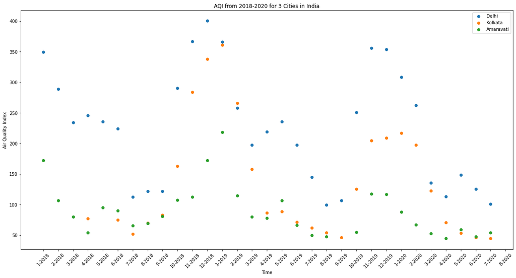

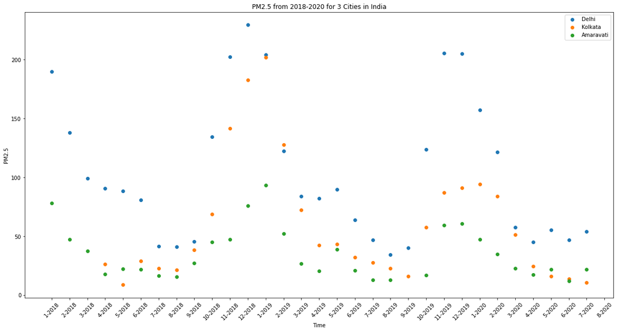

```python
#This section of code will make scatter plots for AQI and PM2.5 over the years of 2018-2020 in the 3 cities above

#Labels created for the ticks in the graph. Contains all 12 months of the years 2018-2020.
month_year_label = ["1-2018", "2-2018", "3-2018", "4-2018", "5-2018", "6-2018", "7-2018", "8-2018", "9-2018", "10-2018", "11-2018", "12-2018",
                    "1-2019", "2-2019", "3-2019", "4-2019", "5-2019", "6-2019", "7-2019", "8-2019", "9-2019", "10-2019", "11-2019", "12-2019",
                    "1-2020", "2-2020", "3-2020", "4-2020", "5-2020", "6-2020", "7-2020", "8-2020", "9-2020", "10-2020", "11-2020", "12-2020"]

#A function to create a scatter plot for each measure or component (e.g. AQI, PM2.5) that compares values for 3 different cities
def plot_per_measure(measure):
  #For each of the 3 cities
  for city in cities:
    #A dictionary that stores all months in 2018-2020 with a total sum of the measure and number of values that were read
    measure_months = {key: {"total":0, "count":0} for key in month_year_label}

    #Extracts all rows that had the current city
    city_df = city_day[(city_day['City'] == city)]

    #For each row, ind = row number
    for ind in city_df.index:
      #Converts the string date from the current row into a datetime
      date = pd.to_datetime(city_df["Date"][ind], format="%Y-%m-%d")
      #Creates a string of month-year (like how the labels are formatted)
      month_year_str = str(date.month) + "-" + str(date.year)

      #If the value of the measure is not missing and the date for the current row is in 2018 or later
      if not np.isnan(city_df[measure][ind]) and date.year >= 2018:
        #Increment the measure's total by the value of the measure and count by 1 for the corresponding month-year
        measure_months[month_year_str]["total"] = measure_months[month_year_str]["total"] + city_df[measure][ind]
        measure_months[month_year_str]["count"] = measure_months[month_year_str]["count"] + 1
    #Calculates the averages of the measure for each month in 2018-2020
    #If the count was 0, meaning no data for the measure in that month, then nan is used instead
    avgs = map(lambda val: val["total"]/val["count"] if val["count"] != 0 else np.nan, measure_months.values())

    #Plots the scatter plot of measure over time for the current city
    plt.scatter(month_year_label, list(avgs), label=city)

#Changes the size of the plots
plt.rcParams['figure.figsize'] = [20, 10]

#Creates a plot of AQI over time for the 3 cities
plot_per_measure("AQI")
plt.title("AQI from 2018-2020 for 3 Cities in India")
plt.ylabel("Air Quality Index")
plt.xlabel("Time")
plt.xticks(rotation=45)
plt.legend()
plt.show()

#Creates a plot of PM2.5 over time for the 3 cities
plot_per_measure("PM2.5")
plt.title("PM2.5 from 2018-2020 for 3 Cities in India")
plt.ylabel("PM2.5")
plt.xlabel("Time")
plt.xticks(rotation=45)
plt.legend()
plt.show()
```

**Interpreting the Scatter Plot**

The scatter plot shows how varied the AQI values are throughout the years, as well as shows a drop in AQI values for all three cities at the beginning of 2020 during the period when the lockdown in India just began. This is really interesting to see, especially as it indicates that there is a way for air quality to recover in even the most severe locations.

**Using Regression to Predict AQI**

Next, we wanted to create a regression model for AQI over time, and use a violin plot to show the range of residual values. This will help us get an indication of whether or not our regression was successful at predicting the AQI values based on time alone. For more information on how to create the violin plot, check out [this resource](https://seaborn.pydata.org/generated/seaborn.violinplot.html). For more information about linear regression, you can visit [this website](https://scikit-learn.org/stable/modules/generated/sklearn.linear_model.LinearRegression.html).

```
Regression line of AQI over Year for the City: Delhi
Y =  [43053.07896395]  +  [-21.21356727] X
X = Year, Y = Predicted AQI
```

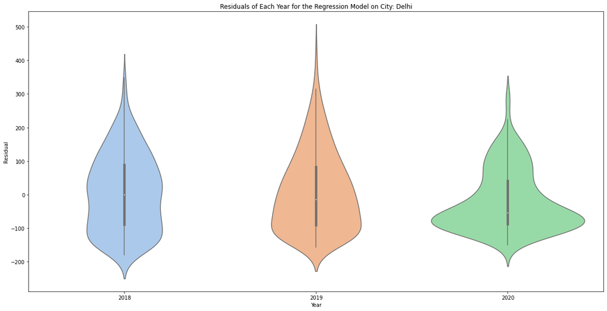

```
Regression line of AQI over Year for the City: Kolkata
Y =  [38081.41081437]  +  [-18.79218313] X
X = Year, Y = Predicted AQI
```

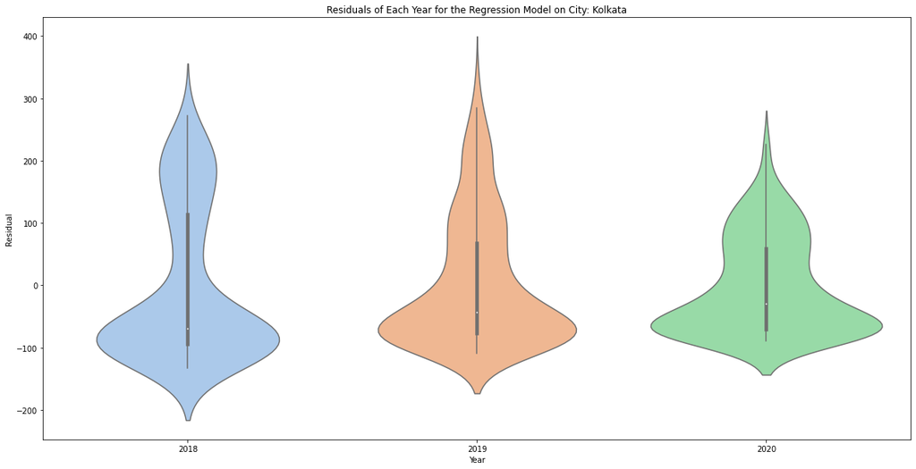

```
Regression line of AQI over Year for the City: Amaravati
Y =  [53032.22277071]  +  [-26.22251248] X
X = Year, Y = Predicted AQI
```

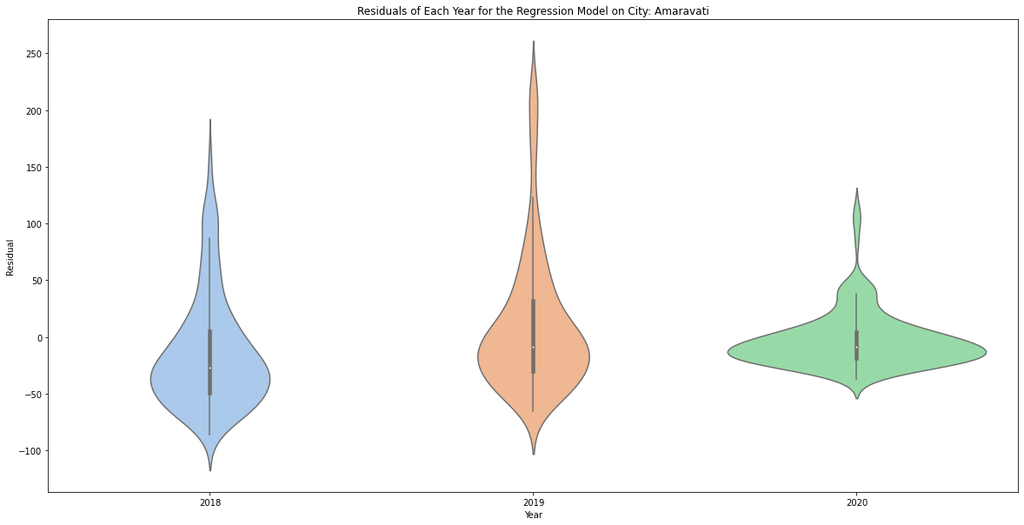

```python
#This section of code creates regression model for AQI over time and a volin plot of its residuals for each of the 3 cities
from sklearn.linear_model import LinearRegression
from sklearn.preprocessing import PolynomialFeatures
import seaborn as sns
import warnings
warnings.filterwarnings('ignore')

#A function to calculate the regression model and create violin plot of the residuals for the current city
def regressionForCityDataframe(df, city):
  #Creates a new regression model
  reg = LinearRegression()
  #Converts the string form of the date to datetime and grabs the year of the date
  df['Year'] = pd.DatetimeIndex(df['Date']).year
  #Fits the regression model with x = year, y = AQI
  reg.fit(df[['Year']], df[['AQI']])

  #Prints the regression line in the form of a function
  print("Regression line of AQI over Year for the City: " + str(city))
  print("Y = ", reg.intercept_, " + ", reg.coef_[0], "X")
  print("X = Year, Y = Predicted AQI")

  #Predicting using the regression model on the actual year data from 2018 onwards
  df=df[df['Year']>=2018]
  predicted = reg.predict(df[['Year']])
  df['Predicted_AQI'] = predicted
  #Calculates the residuals
  df['Residual'] = df['AQI'] - df['Predicted_AQI']

  #Creates and displays a violin plot that shows the residuals for the regression model of the current city
  fig, ax = plt.subplots()
  ax = sns.violinplot(x="Year", y="Residual", data=df, palette='pastel')
  ax.set_xlabel("Year")
  ax.set_ylabel("Residual")
  ax.set_title("Residuals of Each Year for the Regression Model on City: " + str(city))
  plt.show()

#For each of the 3 cities
for city in cities:
  #Extracts all rows that are for the current city and drop any rows that have missing data for the columns AQI, and Date
  city_df=city_day[(city_day['City'] == city)].dropna(subset=['AQI', 'Date'])
  #Calculates regression model and create a violin plot of the residuals for the current city
  regressionForCityDataframe(city_df, city)
  print("")
```

**Interpreting the Violin Plot**

Based on this violin plot, we can see that the range of the residual values is pretty broad. This makes sense based on the previous scatter plot we created, as the data itself varied from season to season within the year. This is likely due to the environmental changes during different seasons in India, as well as the period of lockdown that occurred in 2020 as a result of the COVID-19 pandemic.

**Predicting AQI Using an Interaction Between Year and PM2.5**

Based on our previous data exploration, we learned that PM2.5 was among the strongest factors that influenced the AQI index. Perhaps we can use this, and add an interaction term between PM2.5 and year. For our hypothesis test, we will refit the regression equation using a transferred x value which represents the interaction between the year and PM2.5 values. Then, we will predict the AQI values and use [statsmodels](https://www.statsmodels.org/stable/index.html) to print the hypothesis test summary.

```python
#This section of code will fit a linear regression model for AQI using time with an interaction term of PM2.5

import statsmodels.api as sm
import statsmodels.formula.api as smf

#A function to calculate the regression model with an interaction term and displays the summary of the model with its p-values for the given city
def interactionForCity(df, city):
  #Adds the interaction between year and PM2.5 value to predict AQI
  df['Year'] = pd.DatetimeIndex(df['Date']).year
  df=df[df['Year']>=2018]
  year_pm25df = df[['Year','PM2.5']]
  poly = PolynomialFeatures(interaction_only=True,include_bias = False)
  x_inter=poly.fit_transform(year_pm25df)

  #Fits the regression with the transformed x values
  reg = LinearRegression()
  reg.fit(x_inter, df[['AQI']])

  #Prints the coefficients and intercept in the form of an equation
  print("New regression model using Year AND PM2.5 as the interaction term for the City: " + str(city))
  print("Y = ", reg.intercept_[0], " + ", reg.coef_[0][0], "X1 + ", reg.coef_[0][1], "X2 + ", reg.coef_[0][2], "X1 X2")
  print("Y = Predicted AQI, X1 = Year, X2 = PM2.5")

  print('-------------------------------------------------------------------------')

  #Fit the model using the AQI actual values and the transformed x values
  model = sm.OLS(df[['AQI']], x_inter).fit()

  print("\nPVALUES for City: " + str(city))
  #Prints p value
  print(model.pvalues)

  print('\n-------------------------------------------------------------------------')

#For each of the 3 cities
for city in cities:
  #Extracts all rows that are for the current city and drop any rows that have missing data for the columns AQI, Date, PM2.5
  city_df=city_day[(city_day['City'] == city)].dropna(subset=['AQI', 'Date', 'PM2.5'])

  interactionForCity(city_df, city)
```

```
New regression model using Year AND PM2.5 as the interaction term for the City: Delhi
Y =  22756.35448752142  +  -11.22959674637138 X1 +  -25.32938522024839 X2 +  0.01321792983154424 X1 X2
Y = Predicted AQI, X1 = Year, X2 = PM2.5
-------------------------------------------------------------------------

PVALUES for City: Delhi
x1    9.370507e-182
x2     3.383634e-05
x3     4.067797e-05
dtype: float64

-------------------------------------------------------------------------
New regression model using Year AND PM2.5 as the interaction term for the City: Kolkata
Y =  5965.2139418108545  +  -2.9412599967532316 X1 +  -246.44840348440647 X2 +  0.122943595005097 X1 X2
Y = Predicted AQI, X1 = Year, X2 = PM2.5
-------------------------------------------------------------------------

PVALUES for City: Kolkata
x1    1.735798e-64
x2    5.110504e-08
x3    3.886908e-08
dtype: float64

-------------------------------------------------------------------------
New regression model using Year AND PM2.5 as the interaction term for the City: Amaravati
Y =  21653.167789180417  +  -10.711833970320331 X1 +  -82.45988528193911 X2 +  0.041719868362363854 X1 X2
Y = Predicted AQI, X1 = Year, X2 = PM2.5
-------------------------------------------------------------------------

PVALUES for City: Amaravati
x1    1.019263e-73
x2    8.205639e-12
x3    1.018720e-11
dtype: float64

-------------------------------------------------------------------------
```

**Interpreting the Hypothesis Test**

Our null hypothesis, which was that there’s no relationship between the PM2.5 and year data, can be rejected as we have obtained p-values less than .05 for all three cities. This means that we can use regression to predict the air quality values based on the given information in this dataset. This can be extremely useful in future situations when understanding situations where the PM2.5 values might increase, which would lead to an increase in the AQI index, and overall have negative consequences for the surrounding environment.

**Conclusion**

Through our data exploration, we were able to see how three different cities with a diverse range of overall air quality might have their AQI index be impacted over time as a result of particulate matter. We were able to use both linear regression and the decision tree classifier to gain insights from the data, such as which components have a higher impact on the severity of the overall air quality, and whether or not the year and PM2.5 have interactions with one another.

**Future Goals and Applications**

In the future, there is still so much we can learn from this dataset. It would be interesting to focus specifically on cities with similar AQI bucket values (only severe or only good), and look at which factors interact the most with those cities. It would also be very valuable to pair the insights gained about air quality from these cities with data about their transportation or farming infrastructure, which could further aid understanding of what can be done to improve air quality and reduce harmful emissions into the environment.